# Mentors Participation in SGSF’s Events

SUPERGirls SHINE Foundation

2023-04-26

### Our goals of interest in this project would be to analyze and visualize the total participation of SGSF Mentors by their names in SGSF’s past events in order to know who is the number 1 mentor whith the highest number of participations.

```r
library(tidyverse)
library(RColorBrewer)
library(plotly)
library(plyr)
library(gt)
library(stringr)
library(stringi)
library(mapquestr)
library(leaflet)

data<- readr::read_csv("Mentors participation.csv")
```

### Here is a glimpse of what we will be working with:

```r
colnames(data)
```

```
##  [1] "Last Name"      "First Name"     "Company"        "Job Title"
##  [5] "Email Address"  "Cell Number"    "Matching"       "Status Updates"
##  [9] "3/20/2023"      "3/4/2023"       "2/18/2023"      "2/11/2023"
## [13] "12/19/2023"     "9/23/2023"
```

The dates refers to SGSF’s events. For confidentiality, the dataset won’t be shown.

### Prior to counting the total participation of each mentors, the data needs some preprocessing steps:

1. Mentors’ Last Name and Fist Name combination in one column.
2. Replacing the missing values with “not present”.

```r
data$Name<- paste(data$`Last Name`,',',data$`First Name`)
data<-data %>% replace(is.na(.), "not present")
```

Now, our dataset is ready for the countings in numbers and in percentages.

### Adding the counting columns to our data, below are all the dataset’s variables. Our variables of interest for the visualizations are the following:

1. “Name” : The Last Name, First Name.
2. “Presence_counting” : The counting of attended events for each mentor.
3. “Percentage” : The percentage of events attended out of the total number of events for each mentor.

```r
data$Presence_counting <- apply(data, 1, function(x) length(which(x=="present")))
data<-  mutate(data,Percentage= round(Presence_counting*100/6))
colnames(data)
```

```
##  [1] "Last Name"         "First Name"        "Company"
##  [4] "Job Title"         "Email Address"     "Cell Number"
##  [7] "Matching"          "Status Updates"    "3/20/2023"
## [10] "3/4/2023"          "2/18/2023"         "2/11/2023"
## [13] "12/19/2023"        "9/23/2023"         "Name"
## [16] "Presence_counting" "Percentage"
```

### Mentors Participation in SGSF’s Events in %

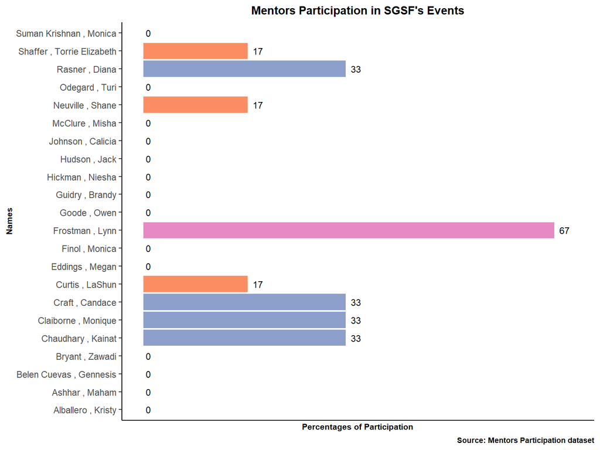

```r
colourCount = length(unique(data$Percentage))
getPalette = colorRampPalette(brewer.pal(colourCount, "Set2"))

p1<-ggplot(data,  aes(x= data$Name, y=data$Percentage, fill= factor(data$Percentage)))+

  geom_bar(stat = 'identity',width=0.9)+
  ggtitle("Mentors Participation in SGSF's Events") +
  theme_classic()+
  coord_flip()+
  geom_text(aes(label=Percentage),size = 3, hjust = -0.5,position = position_stack(vjust = 1),
    inherit.aes = TRUE)+
    labs(y="Percentages of Participation",x="Names", caption = "Source: Mentors Participation dataset")+
  scale_y_continuous(labels = NULL, breaks = NULL,limits = c(0,70))+

  theme(legend.position = "none",
       title = element_text(size = 9, face = "bold"),
        plot.title = element_text(hjust = 0.5),
        axis.title.x = element_text(size = 8, face = "bold"),
        axis.title.y = element_text(size = 8, face = "bold"),
        axis.ticks.x =  element_blank(),

        panel.grid.minor = element_blank())
p1 +scale_fill_manual(values =getPalette(colourCount))
```

### Mentors Participation in SGSF’s Events in % and Ascending order

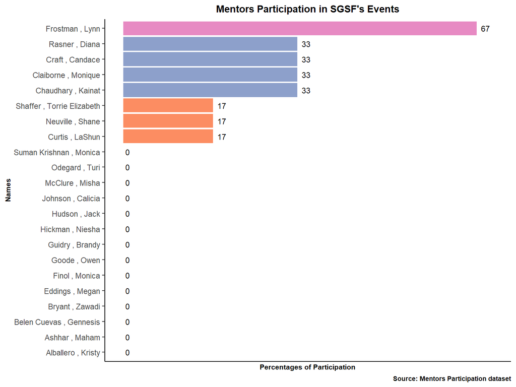

```r
colourCount = length(unique(data$Percentage))
getPalette = colorRampPalette(brewer.pal(colourCount, "Set2"))

p2<-ggplot(data,  aes(x= reorder(data$Name, +data$Percentage), y=data$Percentage, fill= factor(data$Percentage)))+

  geom_bar(stat = 'identity',width=0.9)+
  ggtitle("Mentors Participation in SGSF's Events") +
  theme_classic()+
  coord_flip()+
  geom_text(aes(label=Percentage),size = 3, hjust = -0.5,position = position_stack(vjust = 1),
    inherit.aes = TRUE)+
    labs(y="Percentages of Participation",x="Names", caption = "Source: Mentors Participation dataset")+
  scale_y_continuous(labels = NULL, breaks = NULL,limits = c(0,70))+

  theme(legend.position = "none",
       title = element_text(size = 9, face = "bold"),
        plot.title = element_text(hjust = 0.5),
        axis.title.x = element_text(size = 8, face = "bold"),
        axis.title.y = element_text(size = 8, face = "bold"),
        axis.ticks.x =  element_blank(),

        panel.grid.minor = element_blank())
p2 +scale_fill_manual(values =getPalette(colourCount))
```

### Mentors Participation in SGSF’s Events in Numbers

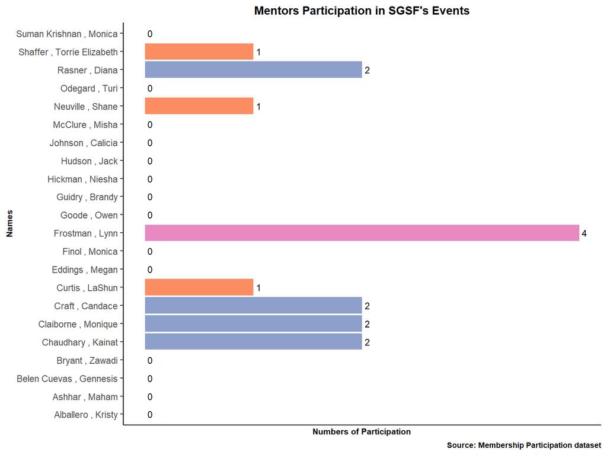

```r
p3<-ggplot(data,  aes(x= Name,y= Presence_counting, fill= factor(data$Presence_counting)))+

  geom_col(stat = 'identity')+
  ggtitle("Mentors Participation in SGSF's Events") +
  theme_classic()+
  coord_flip()+
  geom_text(aes(label=Presence_counting),size = 3, hjust = -0.5,position = position_stack(vjust = 1),
    inherit.aes = TRUE)+
    labs(y="Numbers of Participation",x="Names", caption = "Source: Membership Participation dataset")+

  scale_y_continuous(labels = NULL, breaks = NULL)+

  theme(legend.position = "none",
       title = element_text(size = 9, face = "bold"),
        plot.title = element_text(hjust = 0.5),
        axis.title.x = element_text(size = 8, face = "bold"),
        axis.title.y = element_text(size = 8, face = "bold"),
        axis.ticks.x =  element_blank(),

        panel.grid.minor = element_blank())
p3 +scale_fill_manual(values =getPalette(colourCount))
```

### Mentors Participation in SGSF’s Events in Numbers and Ascending order

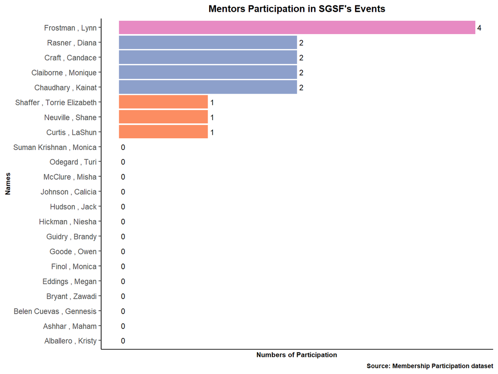

```r
p4<-ggplot(data,  aes(x= reorder(Name, + Presence_counting),y= Presence_counting, fill= factor(data$Presence_counting)))+
  geom_col(stat = 'identity')+
  ggtitle("Mentors Participation in SGSF's Events") +
  theme_classic()+
  coord_flip()+
  geom_text(aes(label=Presence_counting),size = 3, hjust = -0.5,position = position_stack(vjust = 1),
    inherit.aes = TRUE)+
    labs(y="Numbers of Participation",x="Names", caption = "Source: Membership Participation dataset")+

  scale_y_continuous(labels = NULL, breaks = NULL)+

  theme(legend.position = "none",
       title = element_text(size = 9, face = "bold"),
        plot.title = element_text(hjust = 0.5),
        axis.title.x = element_text(size = 8, face = "bold"),
        axis.title.y = element_text(size = 8, face = "bold"),
        axis.ticks.x =  element_blank(),

        panel.grid.minor = element_blank())
p4 +scale_fill_manual(values =getPalette(colourCount))
```

### Observation:

- Lynn Frostman is the mentor who attended the most compared to other mentors: 4 events out of 6 which is 67% of the events that she was invited to.